# Chapter 2 R Code

Yang Li

2024-09-06

## Two-sample t Test

We still use `t.test` to perform two-sample t tests in R. The syntax is

```
t.test(x, y = NULL,
       alternative = c("two.sided", "less", "greater"),
       mu = 0, paired = FALSE, var.equal = FALSE,
       conf.level = 0.95, ...)
```

- `x`: a (non-empty) numeric vector of data values (required for both one-sample and two-sample tests).
- `y`: an optional (non-empty) numeric vector of data values (needed for two-sample tests).
- `alternative`: a character string specifying the alternative hypothesis, must be one of “`two.sided`” (default), “`greater`” or “`less`”. You can specify just the initial letter.
- `mu`: a number $\mu_0$ indicating the true value of the mean in one-sample tests ($H_0: \mu=\mu_0$), or difference in means if you are performing a two sample test ($H_0: \mu_1-\mu_2=\mu_0$).
- `paired`: a logical indicating whether you want a paired t-test. Default value is not paired.
- `var.equal`: a logical variable indicating whether to treat the two variances as being equal. If `var.equal=TRUE` then the pooled variance $s^2_p = \frac{\text{df}_1\times s^2_1 + \text{df}_2 \times s^2_2}{\text{df}_1 + \text{df}_2}$ is used to estimate the variance. If `var.equal=FALSE` then the Satterthwaite approximation to the degrees of freedom $\text{df} = \frac{(n_1-1)(n_2-1)}{(1-c)^2(n_1-1)+c^2(n_2-1)} \text{ with } c=\frac{\frac{s^2_1}{n_1}}{\frac{s^2_1}{n_1}+\frac{s^2_2}{n_2}}$ is used.
- `conf.level`: confidence level of the interval. Default value is $\alpha=0.05$.

### Example

Let’s try exercise 6.6 from the textbook.

> The Department of Natural Resources (DNR) received a complaint from recreational fishermen that a community was releasing sewage into the river where they fished. These types of releases lower the level of dissolved oxygen in the river and hence cause damage to the fish residing in the river. An inspector from the DNR designs a study to investigate the fishermen’s claim. Fifteen water samples are selected at locations on the river upstream from the community and fifteen samples are selected downstream from the community. The dissolved oxygen readings in parts per million (ppm) are given in the following table.

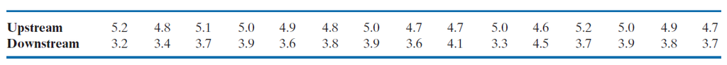

> Question: In order for the discharge to have an impact on fish health, there needs to be at least an 0.5 ppm reduction in the dissolved oxygen. Do the data provide sufficient evidence that there is a large enough reduction in the mean dissolved oxygen between the upstream and downstream water in the river to impact the health of the fish? Use $\alpha=0.01$.

First, we need to load the data into R. Since the data set is very small, we can input them one by one.

```r
upstream <- c(5.2, 4.8, 5.1, 5, 4.9, 4.8, 5, 4.7, 4.7, 5, 4.6, 5.2, 5, 4.9, 4.7)
downstream <- c(3.2, 3.4, 3.7, 3.9, 3.6, 3.8, 3.9, 3.6, 4.1, 3.3, 4.5, 3.7, 3.9, 3.8, 3.7)
```

Note that $\mu_0=0.5$ and $\alpha=0.01$. We are testing $H_0: \mu_{\text{up}}-\mu_{\text{down}} \leq 0.5$ versus $H_a: \mu_{\text{up}} -\mu_{\text{down}}> 0.5$. The R code is the following.

```r
t.test(x=upstream, y=downstream, alternative="g", mu=0.5, var.equal=TRUE, conf.level=0.99)
```

```
##
##  Two Sample t-test
##
## data:  upstream and downstream
## t = 6.9625, df = 28, p-value = 7.166e-08
## alternative hypothesis: true difference in means is greater than 0.5
## 99 percent confidence interval:
##  0.9304355       Inf
## sample estimates:
## mean of x mean of y
##  4.906667  3.740000
```

The p-value is very small, so we need to reject $H_0$ and claim that the difference in the mean dissolved oxygen between the upstream and downstream is greater than 0.5 and thus the health of the fish is impacted.

### Paired Test

For paired data, let’s use the cream example from the lecture.

```r
cream1 <- c(17.6, 20.2, 19.5, 11.5, 13, 16.3, 15.3, 14.8, 22.1, 18.4)
cream2 <- c(17.3, 19.1, 18.4, 11.3, 12.5, 15.8, 14.9, 14.2, 21.5, 17.5)
```

In this test, $H_0$ is $\mu_1=\mu_2$ and $H_a$ is $\mu_1 \neq \mu_2$. If you do it the WRONG way while assuming independence, $H_0$ won’t be rejected as shown by the following code.

```r
t.test(cream1, cream2)
```

```
##
##  Welch Two Sample t-test
##
## data:  cream1 and cream2
## t = 0.43025, df = 17.934, p-value = 0.6721
## alternative hypothesis: true difference in means is not equal to 0
## 95 percent confidence interval:
##  -2.408252  3.648252
## sample estimates:
## mean of x mean of y
##     16.87     16.25
```

The correct way for paired data is to use use option `paired=TRUE` in `t.test`. R will know that the data values have a one-to-one correspondence.

```r
t.test(cream1, cream2, paired=TRUE)
```

```
##
##  Paired t-test
##
## data:  cream1 and cream2
## t = 6.2138, df = 9, p-value = 0.0001563
## alternative hypothesis: true mean difference is not equal to 0
## 95 percent confidence interval:
##  0.3942875 0.8457125
## sample estimates:
## mean difference
##            0.62
```

## Normality

Let’s use the cholesterol reading data from the lecture and first make a simple histogram.

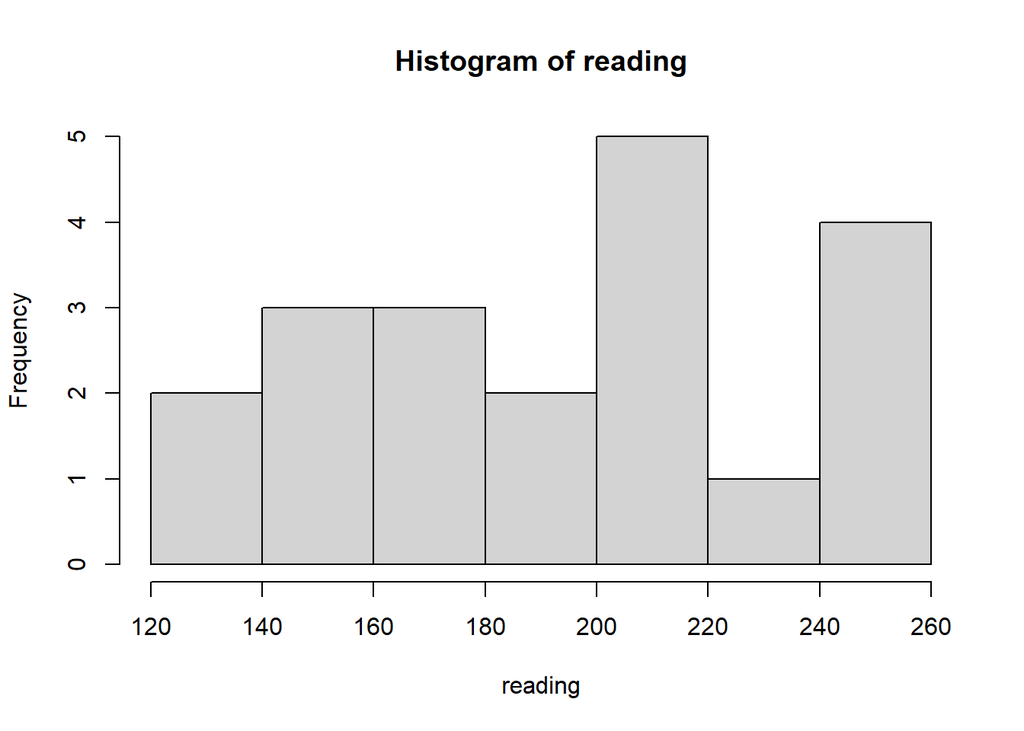

```r
reading <- c(133, 137, 148, 149, 152, 167, 174, 179, 189, 192, 201, 209, 210, 211, 218, 238, 245, 248, 253, 257)
hist(reading)
```

It’s not very conclusive from the histogram. Next, we can make a normal QQ plot.

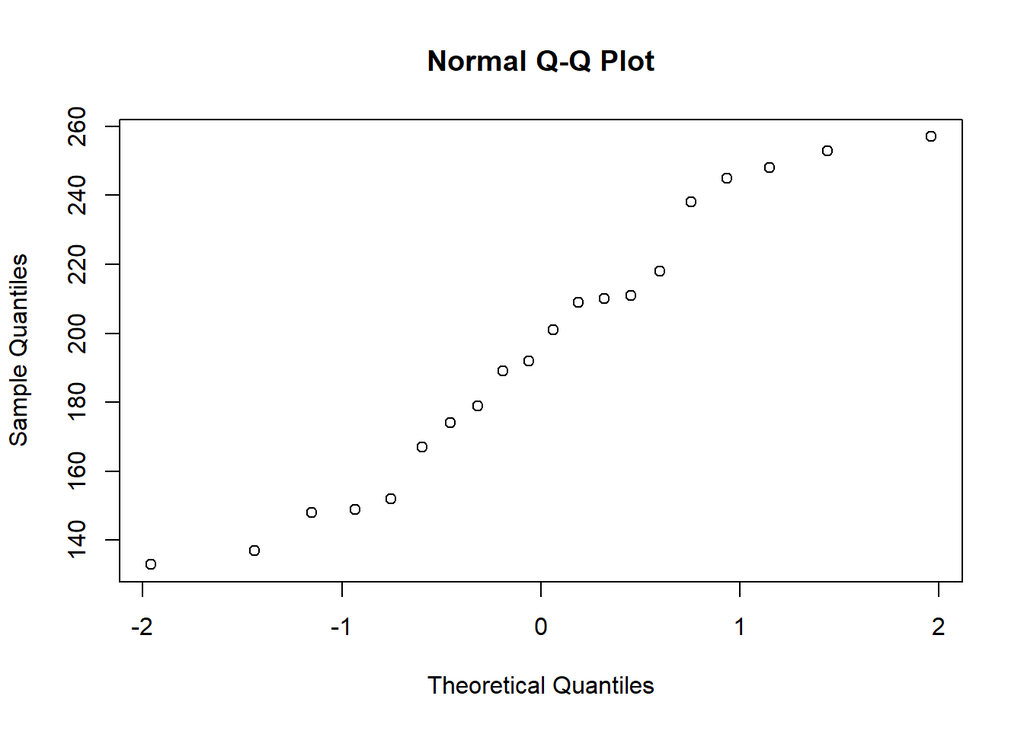

```r
qqnorm(reading)
```

It’s not a perfect straight line, but not very far from it. Then we can use some formal statistical tests to verify normality. Shapiro-Wilk test for normality is a commonly used method which is implemented in base R.

### Shapiro-Wilk test

```r
shapiro.test(reading)
```

```
##
##  Shapiro-Wilk normality test
##
## data:  reading
## W = 0.94537, p-value = 0.3022
```

Some other normality tests are implemented by different packages, such as `nortest`, `goftest` etc.

### Kolmogorov-Smirnov test

```r
library(nortest)
lillie.test(reading)  # KS test in nortest package
```

```
##
##  Lilliefors (Kolmogorov-Smirnov) normality test
##
## data:  reading
## D = 0.11115, p-value = 0.7453
```

```r
ks.test(reading, "pnorm", mean(reading), sd(reading))  # KS test in base R
```

```
##
##  Exact one-sample Kolmogorov-Smirnov test
##
## data:  reading
## D = 0.11115, p-value = 0.9428
## alternative hypothesis: two-sided
```

### Anderson-Darling test

```r
library(goftest)
nortest::ad.test(reading)  # in nortest package
```

```
##
##  Anderson-Darling normality test
##
## data:  reading
## A = 0.31278, p-value = 0.5207
```

```r
goftest::ad.test(reading, "pnorm", mean=mean(reading), sd=sd(reading))  # the same function in goftest package
```

```
##
##  Anderson-Darling test of goodness-of-fit
##  Null hypothesis: Normal distribution
##  with parameters mean = 195.5, sd = 40.0729597766768
##  Parameters assumed to be fixed
##
## data:  reading
## An = 0.31278, p-value = 0.9275
```

### Cramer-von Mises test

```r
nortest::cvm.test(reading)  # in nortest package
```

```
##
##  Cramer-von Mises normality test
##
## data:  reading
## W = 0.037493, p-value = 0.7109
```

```r
goftest::cvm.test(reading, "pnorm", mean=mean(reading), sd=sd(reading))  # the same function in goftest package
```

```
##
##  Cramer-von Mises test of goodness-of-fit
##  Null hypothesis: Normal distribution
##  with parameters mean = 195.5, sd = 40.0729597766768
##  Parameters assumed to be fixed
##
## data:  reading
## omega2 = 0.037493, p-value = 0.9497
```